title: ‘Practical Machine Learning Project: Human Activity Recognition’

author: “Chinasa Ndukwe”

date: “2 octobre 2019”

output: html_document

## Overview

One thing that people regularly do is quantify how much of a particular activity they do, but they rarely quantify how well they do it. In this project, we will be to use data from accelerometers on the belt, forearm, arm, and dumbell to predict the manner in whichthe 6 participants of the data do there exercises.

This report is structured as follow.

First we load and explore the data. In the next step, the data will be use to train a model. This model will then be used to predict how the participant do the exercices.

## Project setup

In this section we load all required library and download the data (training and testing) of this project

### 1. Loading all required library to run to project

```r
library(caret)
```

```r
library(ggplot2)

library(dplyr)
library(parallel)

library(doParallel)
library(rattle)
```

### 2. Download the data from the source

```r
#get the training file url and define the training file name

trainingDataUrl <- "https://d396qusza40orc.cloudfront.net/predmachlearn/pml-training.csv"

trainingFile <- "training.csv"



# define the testing file url and file name

validationDataUrl <- "https://d396qusza40orc.cloudfront.net/predmachlearn/pml-testing.csv"

validationFile <- "testing.csv"

#download the files

if(!file.exists(trainingFile)){
  download.file(trainingDataUrl, trainingFile, method = "curl")
}


if(!file.exists(validationFile)){
  download.file(validationDataUrl,validationFile, method = "curl")
}
```

## Exploring the data

### 1.Loading the data

```r
training <- read.csv(trainingFile, na.strings = c("NA","#DIV/0!", ""))

validation <- read.csv(validationFile, na.strings = c("NA","#DIV/0!", ""))
```

### 2. Exploring training set

```r
#get the structure of the training set
str(training)
```

```
## 'data.frame':    19622 obs. of  160 variables:
##  $ X                       : int  1 2 3 4 5 6 7 8 9 10 ...
##  $ user_name               : Factor w/ 6 levels "adelmo","carlitos",..: 2 2 2 2 2 2 2 2 2 2 ...
##  $ raw_timestamp_part_1    : int  1323084231 1323084231 1323084231 1323084232 1323084232 1323084232 1323084232 1323084232 1323084232 1323084232 ...
##  $ raw_timestamp_part_2    : int  788290 808298 820366 120339 196328 304277 368296 440390 484323 484434 ...
##  $ cvtd_timestamp          : Factor w/ 20 levels "02/12/2011 13:32",..: 9 9 9 9 9 9 9 9 9 9 ...
##  $ new_window              : Factor w/ 2 levels "no","yes": 1 1 1 1 1 1 1 1 1 1 ...
##  $ num_window              : int  11 11 11 12 12 12 12 12 12 12 ...
##  $ roll_belt               : num  1.41 1.41 1.42 1.48 1.48 1.45 1.42 1.42 1.43 1.45 ...
##  $ pitch_belt              : num  8.07 8.07 8.07 8.05 8.07 8.06 8.09 8.13 8.16 8.17 ...
##  $ yaw_belt                : num  -94.4 -94.4 -94.4 -94.4 -94.4 -94.4 -94.4 -94.4 -94.4 -94.4 ...
##  $ total_accel_belt        : int  3 3 3 3 3 3 3 3 3 3 ...
##  $ kurtosis_roll_belt      : num  NA NA NA NA NA NA NA NA NA NA ...
##  $ kurtosis_picth_belt     : num  NA NA NA NA NA NA NA NA NA NA ...
##  $ kurtosis_yaw_belt       : logi  NA NA NA NA NA NA ...
```

[output cut: 86 more lines]

```r
#checking the dimension
dim(training)
```

```
## [1] 19622   160
```

```r
#how many rows by outcome variable
table(training$classe)
```

```
##
##    A    B    C    D    E
## 5580 3797 3422 3216 3607
```

### 3. Exploring validation set

```r
#get the structure of the validation set
str(validation)
```

```
## 'data.frame':    20 obs. of  160 variables:
##  $ X                       : int  1 2 3 4 5 6 7 8 9 10 ...
##  $ user_name               : Factor w/ 6 levels "adelmo","carlitos",..: 6 5 5 1 4 5 5 5 2 3 ...
##  $ raw_timestamp_part_1    : int  1323095002 1322673067 1322673075 1322832789 1322489635 1322673149 1322673128 1322673076 1323084240 1322837822 ...
##  $ raw_timestamp_part_2    : int  868349 778725 342967 560311 814776 510661 766645 54671 916313 384285 ...
##  $ cvtd_timestamp          : Factor w/ 11 levels "02/12/2011 13:33",..: 5 10 10 1 6 11 11 10 3 2 ...
##  $ new_window              : Factor w/ 1 level "no": 1 1 1 1 1 1 1 1 1 1 ...
##  $ num_window              : int  74 431 439 194 235 504 485 440 323 664 ...
##  $ roll_belt               : num  123 1.02 0.87 125 1.35 -5.92 1.2 0.43 0.93 114 ...
##  $ pitch_belt              : num  27 4.87 1.82 -41.6 3.33 1.59 4.44 4.15 6.72 22.4 ...
##  $ yaw_belt                : num  -4.75 -88.9 -88.5 162 -88.6 -87.7 -87.3 -88.5 -93.7 -13.1 ...
##  $ total_accel_belt        : int  20 4 5 17 3 4 4 4 4 18 ...
##  $ kurtosis_roll_belt      : logi  NA NA NA NA NA NA ...
##  $ kurtosis_picth_belt     : logi  NA NA NA NA NA NA ...
##  $ kurtosis_yaw_belt       : logi  NA NA NA NA NA NA ...
```

[output cut: 86 more lines]

```r
#checking the dimension
dim(validation)
```

```
## [1]  20 160
```

### 4. Removing not needed variables

We will first remove the user name variable and the time related variable.

```r
#remove the index variable and the user name variable
training <- select(training, -X, -user_name)

#remove all timestamp data
training <- select(training, -raw_timestamp_part_1, -raw_timestamp_part_2, -cvtd_timestamp)

#remove the window and the window number
training <- select(training, -new_window, -num_window)
```

We count how many missing value we have in the data

```r
# Missing values
colSums(is.na(training))
```

```
##                roll_belt               pitch_belt                 yaw_belt
##                        0                        0                        0
##         total_accel_belt       kurtosis_roll_belt      kurtosis_picth_belt
##                        0                    19226                    19248
##        kurtosis_yaw_belt       skewness_roll_belt     skewness_roll_belt.1
##                    19622                    19225                    19248
##        skewness_yaw_belt            max_roll_belt           max_picth_belt
##                    19622                    19216                    19216
##             max_yaw_belt            min_roll_belt           min_pitch_belt
##                    19226                    19216                    19216
##             min_yaw_belt      amplitude_roll_belt     amplitude_pitch_belt
##                    19226                    19216                    19216
##       amplitude_yaw_belt     var_total_accel_belt            avg_roll_belt
##                    19226                    19216                    19216
##         stddev_roll_belt            var_roll_belt           avg_pitch_belt
##                    19216                    19216                    19216
##        stddev_pitch_belt           var_pitch_belt             avg_yaw_belt
##                    19216                    19216                    19216
##          stddev_yaw_belt             var_yaw_belt             gyros_belt_x
##                    19216                    19216                        0
##             gyros_belt_y             gyros_belt_z             accel_belt_x
##                        0                        0                        0
##             accel_belt_y             accel_belt_z            magnet_belt_x
##                        0                        0                        0
##            magnet_belt_y            magnet_belt_z                 roll_arm
##                        0                        0                        0
##                pitch_arm                  yaw_arm          total_accel_arm
##                        0                        0                        0
##            var_accel_arm             avg_roll_arm          stddev_roll_arm
##                    19216                    19216                    19216
##             var_roll_arm            avg_pitch_arm         stddev_pitch_arm
##                    19216                    19216                    19216
##            var_pitch_arm              avg_yaw_arm           stddev_yaw_arm
##                    19216                    19216                    19216
##              var_yaw_arm              gyros_arm_x              gyros_arm_y
##                    19216                        0                        0
##              gyros_arm_z              accel_arm_x              accel_arm_y
##                        0                        0                        0
##              accel_arm_z             magnet_arm_x             magnet_arm_y
##                        0                        0                        0
```

[output cut: 47 more lines]

```
##                    19216                    19216                    19300
##      total_accel_forearm        var_accel_forearm         avg_roll_forearm
##                        0                    19216                    19216
##      stddev_roll_forearm         var_roll_forearm        avg_pitch_forearm
##                    19216                    19216                    19216
##     stddev_pitch_forearm        var_pitch_forearm          avg_yaw_forearm
##                    19216                    19216                    19216
##       stddev_yaw_forearm          var_yaw_forearm          gyros_forearm_x
##                    19216                    19216                        0
##          gyros_forearm_y          gyros_forearm_z          accel_forearm_x
##                        0                        0                        0
##          accel_forearm_y          accel_forearm_z         magnet_forearm_x
##                        0                        0                        0
##         magnet_forearm_y         magnet_forearm_z                   classe
##                        0                        0                        0
```

We have seen that some column has no missing value while other has 19216 missing value. The training set has 19622 rows.

Therefore those columns has

[1] 97.93089

All the variable with missing values will be removed. The depending variable class does not have any missing values, which is good so far.

We are going to remove all column with NA row is bigger or equal to 19216.

```r
#Remove all NA variables
training <- training [, colSums(is.na(training)) == 0]

dim(training)
```

```
## [1] 19622    53
```

We have 53 variables with no NA.

## Building model

Before to train the model, we prepare our system. In the preparation phase, we prepare the system to run in parallel mode and we set a seed to allow reproductibility of the project.

### 1. Prepare the system for training

```r
# Prepare the system to use parallel processing for performance sake
cluster <- makeCluster(detectCores() - 1)
# convention to leave 1 core for OS
registerDoParallel(cluster)

#set the seed to allow reproductibility
set.seed(1234)

#Partition the data into training and testing set
InTrain<-createDataPartition(y=training$classe,p=0.7,list=FALSE)

training1<-training[InTrain,]
testing <- training[-InTrain,]
```

### 2. Train with Random Forest

```r
control <- trainControl(method="cv", number=5, allowParallel = TRUE)

rfModel <- train(classe~., data=training1, method="rf",  trControl=control, prox = TRUE, verbose=TRUE )

rfModel$finalModel
```

```
##
## Call:
##  randomForest(x = x, y = y, mtry = param$mtry, proximity = TRUE,      verbose = TRUE)
##                Type of random forest: classification
##                      Number of trees: 500
## No. of variables tried at each split: 27
##
##         OOB estimate of  error rate: 0.69%
## Confusion matrix:
##      A    B    C    D    E class.error
## A 3901    3    1    0    1 0.001280082
## B   18 2634    5    1    0 0.009029345
## C    0   19 2368    9    0 0.011686144
## D    0    1   25 2224    2 0.012433393
## E    0    1    4    5 2515 0.003960396
```

```r
#Predict the test set
pred <- predict(rfModel, testing)

#Mesure the result of the prediction
rfConfusionMat <- confusionMatrix(pred, testing$classe)
rfConfusionMat
```

```
## Confusion Matrix and Statistics
##
##           Reference
## Prediction    A    B    C    D    E
##          A 1673    5    0    0    0
##          B    0 1129   14    0    0
##          C    1    5 1010    8    0
##          D    0    0    2  955    0
##          E    0    0    0    1 1082
##
## Overall Statistics
##
##                Accuracy : 0.9939
##                  95% CI : (0.9915, 0.9957)
##     No Information Rate : 0.2845
##     P-Value [Acc > NIR] : < 2.2e-16
##
##                   Kappa : 0.9923
##
##  Mcnemar's Test P-Value : NA
##
## Statistics by Class:
##
##                      Class: A Class: B Class: C Class: D Class: E
## Sensitivity            0.9994   0.9912   0.9844   0.9907   1.0000
## Specificity            0.9988   0.9971   0.9971   0.9996   0.9998
## Pos Pred Value         0.9970   0.9878   0.9863   0.9979   0.9991
## Neg Pred Value         0.9998   0.9979   0.9967   0.9982   1.0000
## Prevalence             0.2845   0.1935   0.1743   0.1638   0.1839
## Detection Rate         0.2843   0.1918   0.1716   0.1623   0.1839
## Detection Prevalence   0.2851   0.1942   0.1740   0.1626   0.1840
## Balanced Accuracy      0.9991   0.9941   0.9908   0.9951   0.9999
```

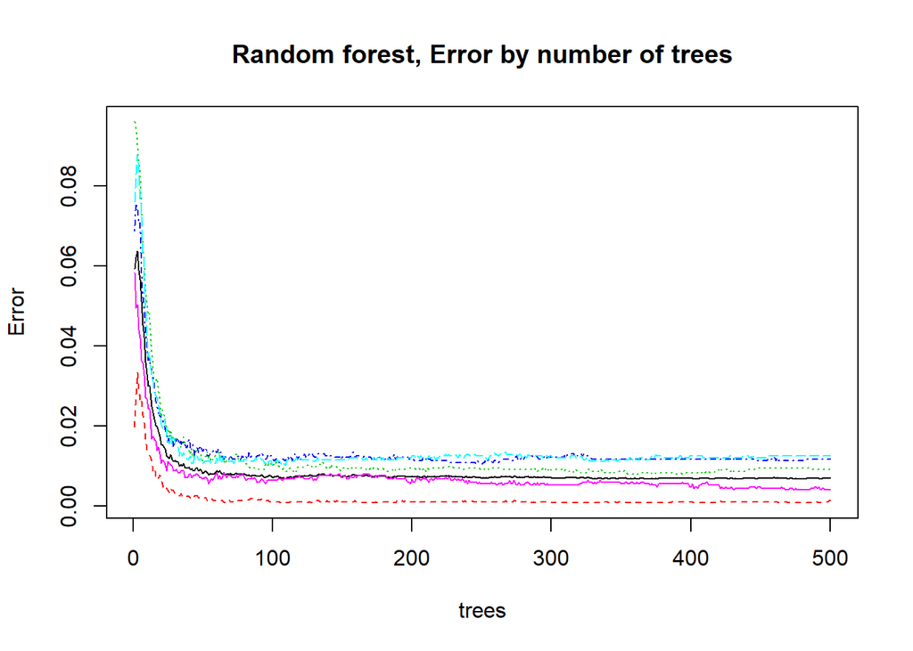

```r
#make the tree plot
plot(rfModel$finalModel, main = "Random forest, Error by number of trees")
```

```r
# The overall accuracy of our first model is
rfConfusionMat$overall['Accuracy']
```

```
##  Accuracy
## 0.9938828
```

The accuracy of the model is good enought. There is no need to try other algorithm. Random Forest does predict with best result.

## Predicting test data

We use the model from random forest to predict test data.

```r
prediction <- predict (rfModel, newdata=validation)

prediction
```

```
##  [1] B A B A A E D B A A B C B A E E A B B B
## Levels: A B C D E
```

## Conclusion

Althought the processing time of the Random forest is high it perform quite good on prediction the classe of exercices.